# IODS course project

Seppo Nyrkkö (seppo.nyrkko at helsinki.fi)

# Introduction to Open Data Science - Course Project

# Chapter 1 - Intro

### Seppo wRites some notes heRe

*Fri Oct 30, 2020*

Here is the link: https://github.com/avaruusseppo/IODS-project

*I have some experience with R already but yet not too familiar with the R markdown. Thanks to Kimmo for giving a hint about R bookdown. Also thanks for the peppy warm up speech!*

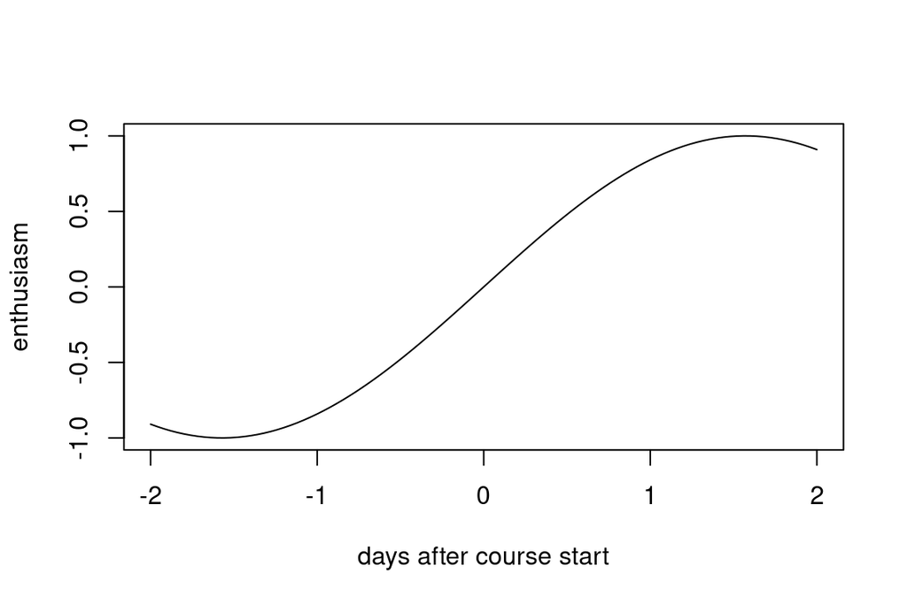

```r
# Let us do something in this "R chunk" .

plot(sin,from=-2,to=2,xlab="days after course start",ylab = "enthusiasm")
```

A **small** gRaph of my musings.

# Chapter 2 - Data analysis exercise

Fri 06 Nov 2020

### i) Loading a prepared data set and examine its contents.

Loading a prepared csv table, containing data from a learning study (International survey of Approaches to Learning, Kimmo Vehkalahti, fall 2016). Metainformation: https://www.mv.helsinki.fi/home/kvehkala/JYTmooc/JYTOPKYS3-meta.txt

```r
lrn14<-read.csv("data/learning2014.csv")
print(dim(lrn14))
```

```
## [1] 166   7
```

```r
str(lrn14)
```

```
## 'data.frame':    166 obs. of  7 variables:
##  $ gender  : Factor w/ 2 levels "F","M": 1 2 1 2 2 1 2 1 2 1 ...
##  $ age     : int  53 55 49 53 49 38 50 37 37 42 ...
##  $ attitude: int  37 31 25 35 37 38 35 29 38 21 ...
##  $ deep    : num  3.58 2.92 3.5 3.5 3.67 ...
##  $ stra    : num  3.38 2.75 3.62 3.12 3.62 ...
##  $ surf    : num  2.58 3.17 2.25 2.25 2.83 ...
##  $ points  : int  25 12 24 10 22 21 21 31 24 26 ...
```

A quick overview of the contents in this data:

This is a learning study on a statistics students, observing the different factors that might relate to a high or low exam score (points) for students of different ages and genders.

The students were interviewed about their attitude towards statistics, and different motivational questions about their modes of learning.

The mode-related questions are grouped in three different categories (deep, surface and strategic). The category modes are averages of the numeric questionnaire results.

By examining the structure, we can see that the data has 166 observations in 7 variable columns.

- Three background attributes given from the informants: **attitude estimate, age and gender**.
- Three pre-processed learning factors are: **surface, deep and strategic**.
- Data “points” describe the exam **points** or the output score. (Note! Zero exam point score rows are filtered out.)

### ii) An overview of the data

The **summary()** function for a data frame in R shows the ranges where the values of variables reside.

```r
# This show summaries of the variables in the data
summary(lrn14)
```

```
##  gender       age           attitude          deep            stra
##  F:110   Min.   :17.00   Min.   :14.00   Min.   :1.583   Min.   :1.250
##  M: 56   1st Qu.:21.00   1st Qu.:26.00   1st Qu.:3.333   1st Qu.:2.625
##          Median :22.00   Median :32.00   Median :3.667   Median :3.188
##          Mean   :25.51   Mean   :31.43   Mean   :3.680   Mean   :3.121
##          3rd Qu.:27.00   3rd Qu.:37.00   3rd Qu.:4.083   3rd Qu.:3.625
##          Max.   :55.00   Max.   :50.00   Max.   :4.917   Max.   :5.000
##       surf           points
##  Min.   :1.583   Min.   : 7.00
##  1st Qu.:2.417   1st Qu.:19.00
##  Median :2.833   Median :23.00
##  Mean   :2.787   Mean   :22.72
##  3rd Qu.:3.167   3rd Qu.:27.75
##  Max.   :4.333   Max.   :33.00
```

The learning mode parameters (*deep, stra, surf*) are averaged from a Likert style (1-5) questionnaire. The *attitude* is the subjective meter of interest towards learning statistics. The *age* is the student’s age in years.

The *exam* points (used as an output variable in this study) vary from 7 to 33. By looking at the 1st and 3rd quantile in the summary output, the score density could be expected to fit in the Gaussian bell curve.

**Simple plot with linear fitting**

We’ll try quickly a scatter plot with matching attitude to exam points. This is quite much what the excel chart wizards do (but nothing more).

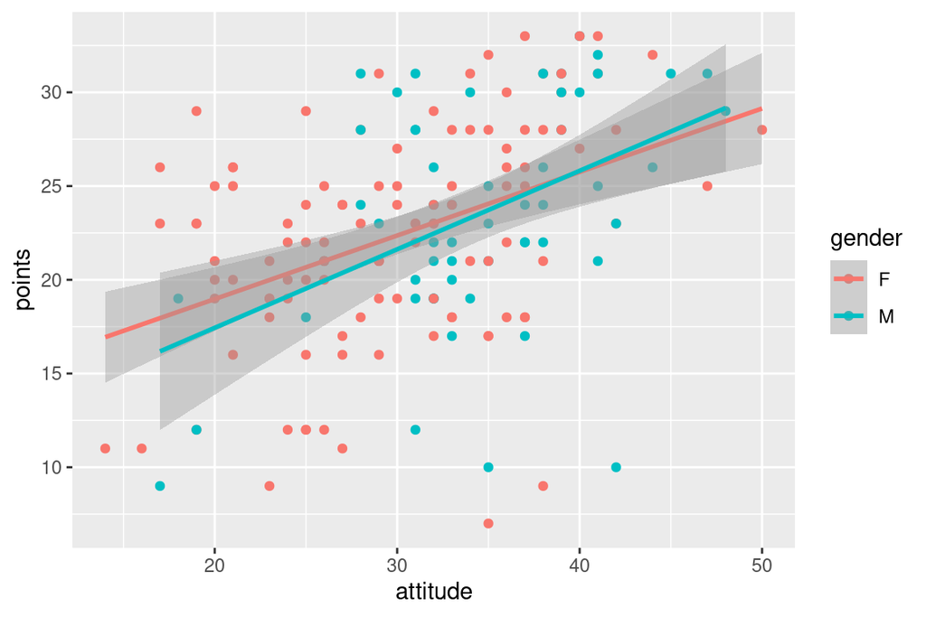

```r
# We need the 'ggplot2' graphics package and ggpairs (from GGally)
library(ggplot2)
library(GGally)
# A scatter plot of students attitude and exam points
qplot(attitude, points, col = gender, data = lrn14) + geom_smooth(method = "lm")
```

When we examine graphically the correlation of attitude to learning and the scores, we can find a positive correlation. What we can see here is that the gender is not too much a factor in the course scores. A great attitude would predict a high score so we would expect a positive correlation.

As a second example, we might be especially interested how the different estimated learning modes affect the score. For instance, the strategic learning shows out promising. A positive correlation is shown as a linear model fitted towards the upper right-hand corner.

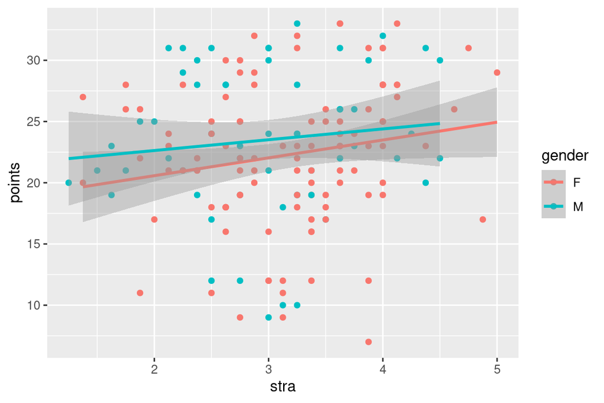

```r
# A scatter plot of students strategic approach on points, fitter by gender
qplot(stra, points, col = gender, data = lrn14) + geom_smooth(method = "lm")
```

Now, instead of examining a single variable’s effect and distribution, we might want to have a graphical overview of them all, with GGally

[figure not shown]

```r
ggpairs(lrn14, lower = list(combo = wrap("facethist", bins = 20)))
```

### iii) Fitting a linear model with function lm()

We continue building a linear model with multiple variables. This model is something that predicts the output variable (exam score) from input variables.

After examining the matrix plot above,I choose three variables: **age, attitude** and **strategic approach**) as explanatory input variables. A regression model is fitted to these variables where exam points is the dependent (output) variable.

Below is a summary of the fitted model and comment, with an interpretation of the R output.

```r
# create a regression model with multiple explanatory variables
my_model2 <- lm(points ~ attitude + stra + age, data = lrn14)
```

The parameter “*points ~ attitude + stra + age*” is a so-called *formula*. It states the dependent variable on the left-hand side of the tilde (“~”) mark. On the right-hand side are the examined coefficients are listed. In this model, the coefficients are ought to be independent of each other.

```r
# print out a summary of the model
summary(my_model2)
```

```
##
## Call:
## lm(formula = points ~ attitude + stra + age, data = lrn14)
##
## Residuals:
##      Min       1Q   Median       3Q      Max
## -18.1149  -3.2003   0.3303   3.4129  10.7599
##
## Coefficients:
##             Estimate Std. Error t value Pr(>|t|)
## (Intercept) 10.89543    2.64834   4.114 6.17e-05 ***
## attitude     0.34808    0.05622   6.191 4.72e-09 ***
## stra         1.00371    0.53434   1.878   0.0621 .
## age         -0.08822    0.05302  -1.664   0.0981 .
## ---
## Signif. codes:  0 '***' 0.001 '**' 0.01 '*' 0.05 '.' 0.1 ' ' 1
##
## Residual standard error: 5.26 on 162 degrees of freedom
## Multiple R-squared:  0.2182, Adjusted R-squared:  0.2037
## F-statistic: 15.07 on 3 and 162 DF,  p-value: 1.07e-08
```

The summary() function for a lm() model shows correlations and F-scores to the coefficients, which are practically the input variables for our model.

At first R outputs a summary of the weighted residuals distribution. These are the error residuals between the estimated and registered output values (points).

The first listed coefficient (intercept) is a baseline, that is a fixed the mean of the output. The following coefficients are expected to affect the output at some correlation. The coefficient correlation is the “slope” of the fitted linear estimate for the effect of the input variable and output.

For each coefficient, R prints out a t-statistic (so-called Student’s test) and a p-value, which reflects the probability of significant correlation between the coefficient and the output variable. R pretty-prints nicely significance codes: E.g. "***" on a strong significance (p<0.001), and “.” on a smaller significance (0.05 < p < 0.1) . (Usually most social studies use the 95 percent confidence rule as the baseline but we can accept this model for now.)

The F-statistic is the so-called test of equality of variances. The smaller the p-value is, the more probable is the alternative hypothesis becomes. In other words a small p-value shows that the model has a meaningful statistical relationship.

The R squared is fraction of variance explained by the model. In other words, if this value is large, the model gives a good fit and there is little or no need to search for additional explaining variables.

### iv) Understanding the fitted model output

The multiple R squared of the model is 0.2182. I would have expected to have a little higher R squared. This gives an impression there would be still more descriptive variables “out there” to be added to the model. Still the R squared is positive so the model is better than fitting a straight horizontal line.

In conclusion, this model can be understood so that the **attitude** variable has a very significant relationship with the exam score, having a p value < 0.001. This means that this alternative hypothesis is very string.

Also the **age** and **strategic learning mode** have somewhat significant relation on the output, since the probability of null hypothesis (ie. no significance) is less than 0.1. It seems the higher age would predict slightly lower exam score, and using strategic learning would produce some extra exam points. Such effect might be worth of further study.

### v) Some useful plots on the fitted model

R has this convenience function for plotting lm() models:

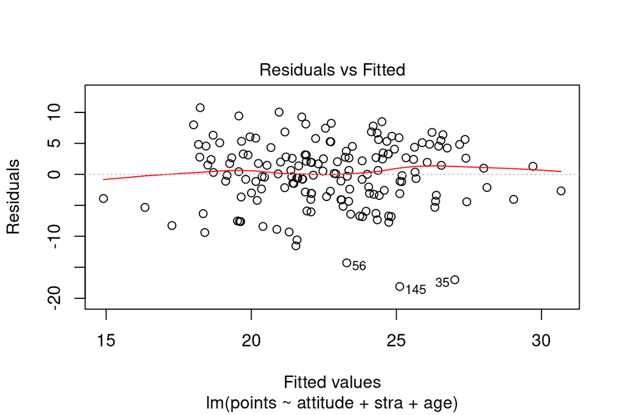

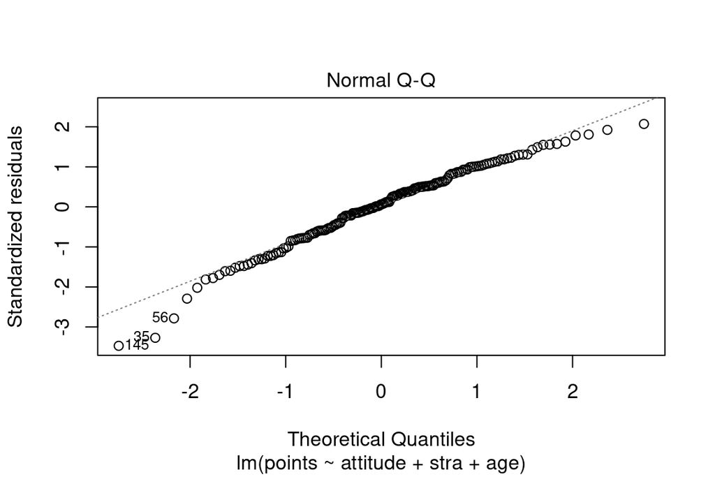

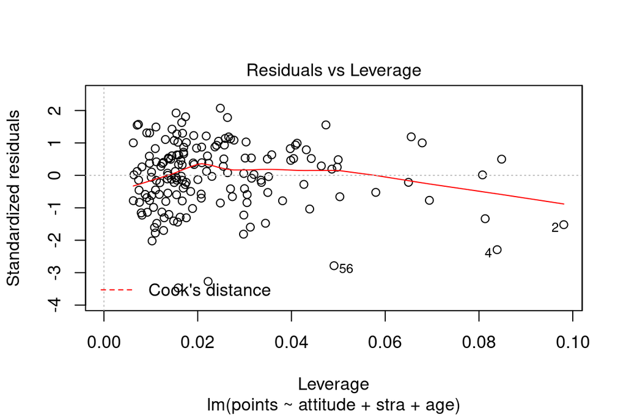

```r
plot(my_model2,c(1,2,5))
```

These graphs help us understand and evaluate, how appropriate our statistical model for estimating the effect of student’s age, attitude towards statistics and their adaptation of strategic learning methods.

The **Residuals vs fitted values** graph shows a general visualization how well this linear model fits the data. If the residuals are uniformly scattered from the low to high end of fitted values, we can be pretty comfortable with these coefficients.

The **Normal Q-Q plot** is a quick visualization, on how well the error residuals distribution follows the Gaussian distribution. If most of the values are laid among the dotted diagonal, we could be assured there is no further systematic “explaining” variable to be examined.

The **Residuals vs leverage** graph is a useful tool for finding *outliers* in a model. An *outlier* is a data point that its output value is exceptionally far from the estimate that is produced from the variables. In other words, any points over the dotted red line would have high influence on the fitted model. Probably any of the points do not have specifically high influence on our model coefficients, and the residuals are quite normally distributed.

# Chapter 3 - Logistic Regression

Fri 13 Nov 2020

## Loading the alcohol data set

From data/alc.csv file:

```r
alc<-read.csv("data/alc.csv")
print(dim(alc))
```

```
## [1] 382  35
```

**A quick overview of the contents in this data:** This is a student performance vs alcohol usage survey data. Data is joined from two course survey data sets, scores averaged, from 382 distinct students with both Portugese and math courses. Added average numberic column alc_use for average alcohol consumption (likert 0…5) and logical column high_use (which is TRUE if alc_use is higher than 2).

```r
colnames(alc)
```

```
##  [1] "school"     "sex"        "age"        "address"    "famsize"
##  [6] "Pstatus"    "Medu"       "Fedu"       "Mjob"       "Fjob"
## [11] "reason"     "nursery"    "internet"   "guardian"   "traveltime"
## [16] "studytime"  "failures"   "schoolsup"  "famsup"     "paid"
## [21] "activities" "higher"     "romantic"   "famrel"     "freetime"
## [26] "goout"      "Dalc"       "Walc"       "health"     "absences"
## [31] "G1"         "G2"         "G3"         "alc_use"    "high_use"
```

Data contains school performance scores (Grades after periods 1-3), absences, alcohol use and some binary background data such as school name, gender, age, home location type. Numeric likert-scale estimates (from 1 to 5 values) on family relations, freetime activity, going out and health. More information at: https://archive.ics.uci.edu/ml/datasets/Student+Performance * NB! added alcohol use columns (average and logical (high consumption))

## Hypothesis about high alochol consumption

Alcohol might be consumed at high rate if the initial G1 grades are low and family relations are at low level. Also stated male gender  
and higher age might induce high alcohol usage.

A graphical summary:

[figure not shown]

```r
library(GGally)
ggpairs(alc,
        columns = c('alc_use','age','sex','famrel','G1'),
        lower = list(combo = wrap("facethist", bins = 30)))
```

[figure not shown]

```r
g1 <- ggplot(alc, aes(x = high_use, y = G1, col = sex))
g1 + geom_boxplot() + ylab("age")+ggtitle("Student initial grades by high alcohol consumption and gender")
```

Then let’s see the age distribution within high and low users.

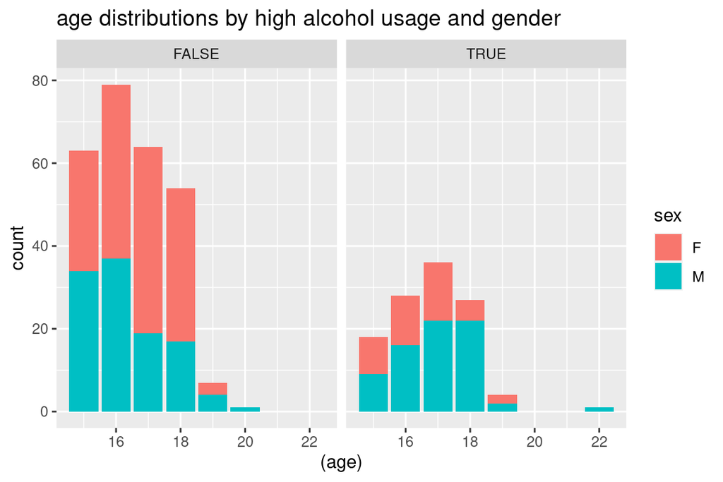

```r
# initialize a plot of 'high_use'
g2 <- ggplot(alc, aes(x=(age), fill=sex))

g2 + facet_wrap("high_use")  + geom_bar() + ggtitle("age distributions by high alcohol usage and gender")
```

Seems like the age distribution might be relevantly different in the high alcohol consumers.

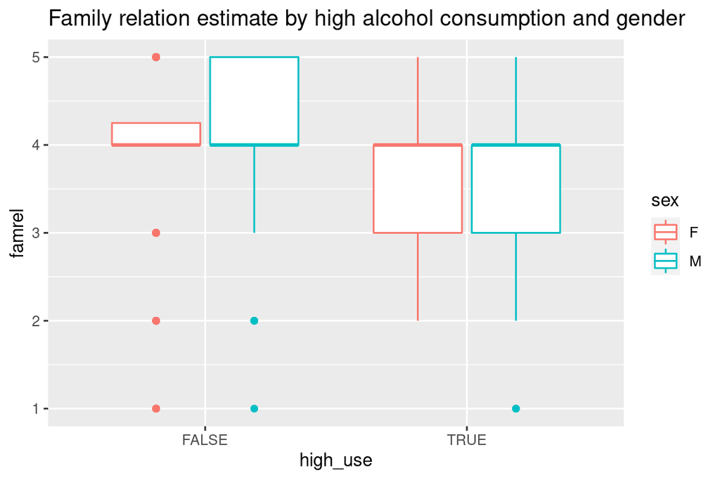

```r
g1 <- ggplot(alc, aes(x = high_use, y = famrel, col = sex))
g1 + geom_boxplot() + ylab("famrel")+ggtitle("Family relation estimate by high alcohol consumption and gender")
```

These seem promising to the hypothesis model.

## Logistic regression

Now I’m about to do a fitting with the binomial distribution (high alcohol consumers vs the control group)

```r
# find the model with glm()
m <- glm(high_use ~ age + sex + G1 + famrel, data = alc, family = "binomial")

summary(m)
```

```
##
## Call:
## glm(formula = high_use ~ age + sex + G1 + famrel, family = "binomial",
##     data = alc)
##
## Deviance Residuals:
##     Min       1Q   Median       3Q      Max
## -1.4499  -0.8193  -0.6569   1.1384   2.1599
##
## Coefficients:
##             Estimate Std. Error z value Pr(>|z|)
## (Intercept)  -1.9968     1.8764  -1.064   0.2872
## age           0.1917     0.1007   1.903   0.0571 .
## sexM          0.9436     0.2378   3.967 7.26e-05 ***
## G1           -0.1141     0.0447  -2.553   0.0107 *
## famrel       -0.3207     0.1262  -2.542   0.0110 *
## ---
## Signif. codes:  0 '***' 0.001 '**' 0.01 '*' 0.05 '.' 0.1 ' ' 1
##
## (Dispersion parameter for binomial family taken to be 1)
##
##     Null deviance: 465.68  on 381  degrees of freedom
## Residual deviance: 432.29  on 377  degrees of freedom
## AIC: 442.29
##
## Number of Fisher Scoring iterations: 4
```

```r
coef(m)
```

```
## (Intercept)         age        sexM          G1      famrel
##  -1.9968299   0.1916833   0.9435755  -0.1141214  -0.3207391
```

All the coefficients seem to be somewhat relevant to predicting high usage. This can be more easily understood as odds ratios, which are the exponents of the coefficients.

**Odds ratios** and their confidence intervals:

```r
# compute odds ratios (OR)
OR <- coef(m) %>% exp

# compute confidence intervals (CI)
CI <- confint(m) %>% exp
cbind(OR, CI)
```

```
##                    OR       2.5 %    97.5 %
## (Intercept) 0.1357650 0.003360881 5.3701291
## age         1.2112868 0.995467029 1.4791035
## sexM        2.5691511 1.620172718 4.1227535
## G1          0.8921496 0.815955982 0.9726699
## famrel      0.7256125 0.565422154 0.9289606
```

**Analysis of the fitted model:** It seems like the good family relations reduce the high alcohol consumption. Higher age and male gender seems also to be an inducing factor to high consumption. Higher grades at first period studies also give a hint towards lesser probable high consumption.

All in all, we’ll keep these coefficients as the factors of our prediction.

## Cross tabulation of a prediction model

First, I create a prediction and probability column, based on the fitting.

```r
# predict() the probability of high_use
probabilities <- predict(m, type = "response")
```

Adding the predicted probabilities to ‘alc’ and using the probabilities to make a prediction of high_use:

```r
alc <- mutate(alc, probability = probabilities)
alc <- mutate(alc, prediction = probability > 0.5)
```

To understand and examine the prediction, let’s see the last ten original classes, predicted probabilities, and “high use” class predictions:

```r
select(alc, age, sex, G1, famrel,high_use, probability, prediction) %>% tail(10)
```

```
##     age sex G1 famrel high_use probability prediction
## 373  19   M  6      4    FALSE   0.6504559       TRUE
## 374  18   M  6      5     TRUE   0.5271286       TRUE
## 375  18   F 12      5    FALSE   0.1795082      FALSE
## 376  18   F  6      4    FALSE   0.3742059      FALSE
## 377  19   F  8      5    FALSE   0.2949394      FALSE
## 378  18   F 11      4    FALSE   0.2525945      FALSE
## 379  18   F  6      2    FALSE   0.5317729       TRUE
## 380  18   F  8      1    FALSE   0.5547198       TRUE
## 381  17   M 12      2     TRUE   0.5484541       TRUE
## 382  18   M 10      4     TRUE   0.4932191      FALSE
```

**Now let’s tabulate the target variable versus the predictions:**

```r
table(high_use = alc$high_use, prediction = alc$prediction)
```

```
##         prediction
## high_use FALSE TRUE
##    FALSE   249   19
##    TRUE     93   21
```

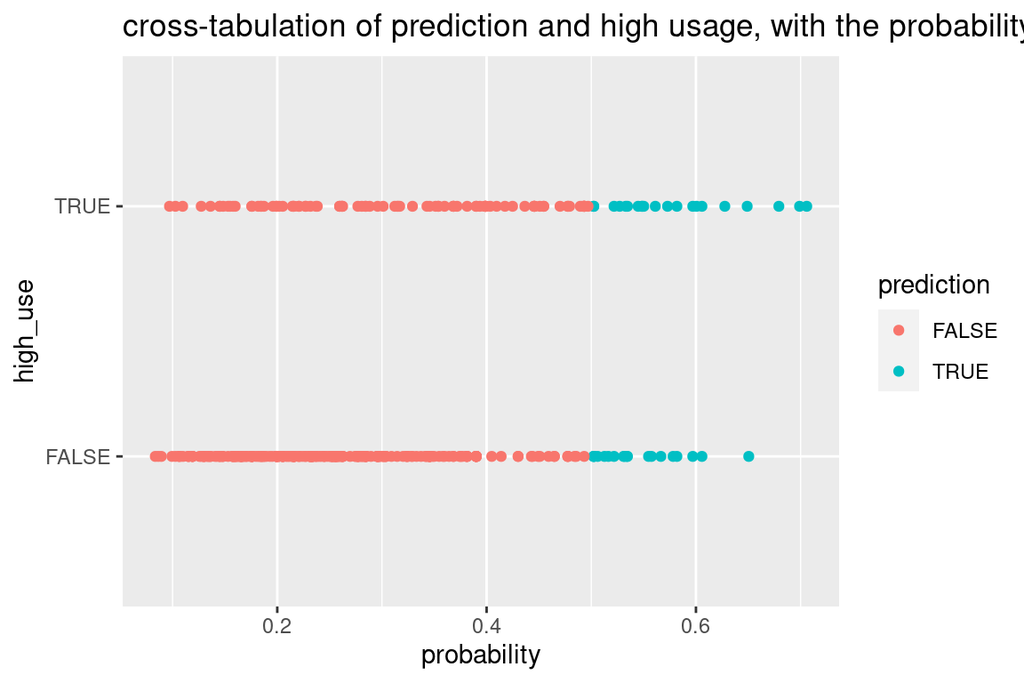

```r
g <- ggplot(alc, aes(x = probability, y = high_use, col = prediction))
g + geom_point() + ggtitle("cross-tabulation of prediction and high usage, with the probability parameter")
```

## 10-fold cross-validation of the prediction

First let’s define a loss function (which is the average error in prediction).

```r
# define a loss function (average prediction error)
loss_func <- function(class, prob) {
  n_wrong <- abs(class - prob) > 0.5
  mean(n_wrong)
}

loss_func(class = alc$high_use, prob = alc$probability)
```

```
## [1] 0.2931937
```

The computed average number of wrong predictions in the (training) data is around 0.29.

Next, we’ll do a ten-fold cross-validation with resampling

```r
library(boot)
cv <- cv.glm(data = alc, cost = loss_func, glmfit = m, K = 10)

cv$delta[1]
```

```
## [1] 0.2931937
```

The average number of wrong predictions in the cross validation is not too small (about 3 wrong out of 10) but we’re quite happy with this.

# Chapter 4 - Clustering and classification

Seppo Nyrkkö *Fri Nov 20, 2020*

## i. Load the Boston data from the MASS package.

```r
library(MASS)
```

## ii. The Boston data

is about housing values in the suburbs of Boston. It comes along with the R MASS data set collection.

*( Harrison, D. and Rubinfeld, D.L. (1978) Hedonic prices and the demand for clean air. J. Environ. Economics and Management 5, 81–102. – Belsley D.A., Kuh, E. and Welsch, R.E. (1980) Regression Diagnostics. Identifying Influential Data and Sources of Collinearity. New York: Wiley. )*

```r
# structure and the dimensions of the Boston data
data("Boston")
str(Boston)
```

```
## 'data.frame':    506 obs. of  14 variables:
##  $ crim   : num  0.00632 0.02731 0.02729 0.03237 0.06905 ...
##  $ zn     : num  18 0 0 0 0 0 12.5 12.5 12.5 12.5 ...
##  $ indus  : num  2.31 7.07 7.07 2.18 2.18 2.18 7.87 7.87 7.87 7.87 ...
##  $ chas   : int  0 0 0 0 0 0 0 0 0 0 ...
##  $ nox    : num  0.538 0.469 0.469 0.458 0.458 0.458 0.524 0.524 0.524 0.524 ...
##  $ rm     : num  6.58 6.42 7.18 7 7.15 ...
##  $ age    : num  65.2 78.9 61.1 45.8 54.2 58.7 66.6 96.1 100 85.9 ...
##  $ dis    : num  4.09 4.97 4.97 6.06 6.06 ...
##  $ rad    : int  1 2 2 3 3 3 5 5 5 5 ...
##  $ tax    : num  296 242 242 222 222 222 311 311 311 311 ...
##  $ ptratio: num  15.3 17.8 17.8 18.7 18.7 18.7 15.2 15.2 15.2 15.2 ...
##  $ black  : num  397 397 393 395 397 ...
##  $ lstat  : num  4.98 9.14 4.03 2.94 5.33 ...
##  $ medv   : num  24 21.6 34.7 33.4 36.2 28.7 22.9 27.1 16.5 18.9 ...
```

```r
summary(Boston)
```

```
##       crim                zn             indus            chas
##  Min.   : 0.00632   Min.   :  0.00   Min.   : 0.46   Min.   :0.00000
##  1st Qu.: 0.08204   1st Qu.:  0.00   1st Qu.: 5.19   1st Qu.:0.00000
##  Median : 0.25651   Median :  0.00   Median : 9.69   Median :0.00000
##  Mean   : 3.61352   Mean   : 11.36   Mean   :11.14   Mean   :0.06917
##  3rd Qu.: 3.67708   3rd Qu.: 12.50   3rd Qu.:18.10   3rd Qu.:0.00000
##  Max.   :88.97620   Max.   :100.00   Max.   :27.74   Max.   :1.00000
##       nox               rm             age              dis
##  Min.   :0.3850   Min.   :3.561   Min.   :  2.90   Min.   : 1.130
##  1st Qu.:0.4490   1st Qu.:5.886   1st Qu.: 45.02   1st Qu.: 2.100
##  Median :0.5380   Median :6.208   Median : 77.50   Median : 3.207
##  Mean   :0.5547   Mean   :6.285   Mean   : 68.57   Mean   : 3.795
##  3rd Qu.:0.6240   3rd Qu.:6.623   3rd Qu.: 94.08   3rd Qu.: 5.188
##  Max.   :0.8710   Max.   :8.780   Max.   :100.00   Max.   :12.127
##       rad              tax           ptratio          black
##  Min.   : 1.000   Min.   :187.0   Min.   :12.60   Min.   :  0.32
##  1st Qu.: 4.000   1st Qu.:279.0   1st Qu.:17.40   1st Qu.:375.38
##  Median : 5.000   Median :330.0   Median :19.05   Median :391.44
##  Mean   : 9.549   Mean   :408.2   Mean   :18.46   Mean   :356.67
##  3rd Qu.:24.000   3rd Qu.:666.0   3rd Qu.:20.20   3rd Qu.:396.23
##  Max.   :24.000   Max.   :711.0   Max.   :22.00   Max.   :396.90
##      lstat            medv
##  Min.   : 1.73   Min.   : 5.00
##  1st Qu.: 6.95   1st Qu.:17.02
##  Median :11.36   Median :21.20
##  Mean   :12.65   Mean   :22.53
##  3rd Qu.:16.95   3rd Qu.:25.00
##  Max.   :37.97   Max.   :50.00
```

506 obs with 14 variables. All numerical.

## iii. Graphical analysis

[figure not shown]

```r
# let's take only a sample, this takes some cpu cycles and produces a grid of tiny plots
ggpairs(Boston[sample(seq(1,nrow(Boston)),size=50),])
```

Some correlation can be seen in the scatter plots. Few distributions are normal, most are skewed or “double-bumped”, meaning there are clusters inside the variables.

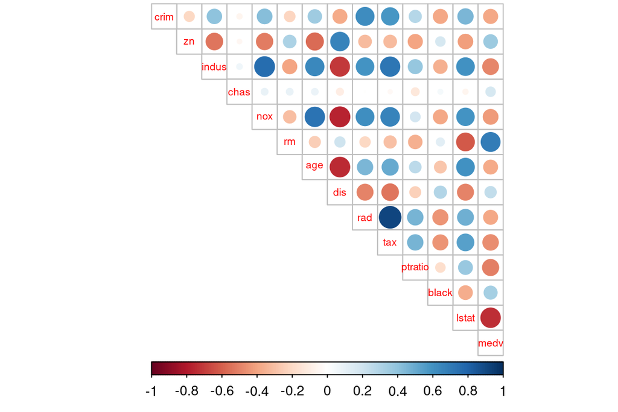

```r
# let us try the cor() matrix and corrplot()
cor_matrix <- cor(Boston)
corrplot(cor_matrix, method="circle", type="upper", cl.pos="b", tl.pos="d", tl.cex=0.6)
```

The correlation plot shows a few interesting positive correlations (radial highways and property tax, nitrogen oxides and industrial acres) and negative correlations (between industrial acres and distance to central areas; and median home values and lower status of population). Seems quite ok.

## iv. Normalize the dataset

```r
# print out summaries of the scaled data.

boston_sc <- as.data.frame(scale(Boston))

summary(boston_sc)
```

```
##       crim                 zn               indus              chas
##  Min.   :-0.419367   Min.   :-0.48724   Min.   :-1.5563   Min.   :-0.2723
##  1st Qu.:-0.410563   1st Qu.:-0.48724   1st Qu.:-0.8668   1st Qu.:-0.2723
##  Median :-0.390280   Median :-0.48724   Median :-0.2109   Median :-0.2723
##  Mean   : 0.000000   Mean   : 0.00000   Mean   : 0.0000   Mean   : 0.0000
##  3rd Qu.: 0.007389   3rd Qu.: 0.04872   3rd Qu.: 1.0150   3rd Qu.:-0.2723
##  Max.   : 9.924110   Max.   : 3.80047   Max.   : 2.4202   Max.   : 3.6648
##       nox                rm               age               dis
##  Min.   :-1.4644   Min.   :-3.8764   Min.   :-2.3331   Min.   :-1.2658
##  1st Qu.:-0.9121   1st Qu.:-0.5681   1st Qu.:-0.8366   1st Qu.:-0.8049
##  Median :-0.1441   Median :-0.1084   Median : 0.3171   Median :-0.2790
##  Mean   : 0.0000   Mean   : 0.0000   Mean   : 0.0000   Mean   : 0.0000
##  3rd Qu.: 0.5981   3rd Qu.: 0.4823   3rd Qu.: 0.9059   3rd Qu.: 0.6617
##  Max.   : 2.7296   Max.   : 3.5515   Max.   : 1.1164   Max.   : 3.9566
##       rad               tax             ptratio            black
##  Min.   :-0.9819   Min.   :-1.3127   Min.   :-2.7047   Min.   :-3.9033
##  1st Qu.:-0.6373   1st Qu.:-0.7668   1st Qu.:-0.4876   1st Qu.: 0.2049
##  Median :-0.5225   Median :-0.4642   Median : 0.2746   Median : 0.3808
##  Mean   : 0.0000   Mean   : 0.0000   Mean   : 0.0000   Mean   : 0.0000
##  3rd Qu.: 1.6596   3rd Qu.: 1.5294   3rd Qu.: 0.8058   3rd Qu.: 0.4332
##  Max.   : 1.6596   Max.   : 1.7964   Max.   : 1.6372   Max.   : 0.4406
##      lstat              medv
##  Min.   :-1.5296   Min.   :-1.9063
##  1st Qu.:-0.7986   1st Qu.:-0.5989
##  Median :-0.1811   Median :-0.1449
##  Mean   : 0.0000   Mean   : 0.0000
##  3rd Qu.: 0.6024   3rd Qu.: 0.2683
##  Max.   : 3.5453   Max.   : 2.9865
```

The means are all zero as expected. There is also the unit variance per each variable.

Now let’s calculate the crime quantiles (from the scaled crime rate).

```r
bins = quantile(boston_sc$crim)
bins
```

```
##           0%          25%          50%          75%         100%
## -0.419366929 -0.410563278 -0.390280295  0.007389247  9.924109610
```

```r
labels = c("low", "med_low", "med_high", "high")
crime <- cut(boston_sc$crim,
             breaks=bins,
             labels=labels,
             include.lowest=TRUE)
boston_sc <- dplyr::select(boston_sc, -crim)
boston_sc <- data.frame(boston_sc, crime)
str(boston_sc)
```

```
## 'data.frame':    506 obs. of  14 variables:
##  $ zn     : num  0.285 -0.487 -0.487 -0.487 -0.487 ...
##  $ indus  : num  -1.287 -0.593 -0.593 -1.306 -1.306 ...
##  $ chas   : num  -0.272 -0.272 -0.272 -0.272 -0.272 ...
##  $ nox    : num  -0.144 -0.74 -0.74 -0.834 -0.834 ...
##  $ rm     : num  0.413 0.194 1.281 1.015 1.227 ...
##  $ age    : num  -0.12 0.367 -0.266 -0.809 -0.511 ...
##  $ dis    : num  0.14 0.557 0.557 1.077 1.077 ...
##  $ rad    : num  -0.982 -0.867 -0.867 -0.752 -0.752 ...
##  $ tax    : num  -0.666 -0.986 -0.986 -1.105 -1.105 ...
##  $ ptratio: num  -1.458 -0.303 -0.303 0.113 0.113 ...
##  $ black  : num  0.441 0.441 0.396 0.416 0.441 ...
##  $ lstat  : num  -1.074 -0.492 -1.208 -1.36 -1.025 ...
##  $ medv   : num  0.16 -0.101 1.323 1.182 1.486 ...
##  $ crime  : Factor w/ 4 levels "low","med_low",..: 1 1 1 1 1 1 2 2 2 2 ...
```

We have a crime factor, great. Now dividing the dataset to train and test sets: 80% goes in training

```r
ind <- sample(seq(1,nrow(boston_sc)), size=nrow(boston_sc) * 0.8)
train <- boston_sc[ind,]
test <- boston_sc[-ind,]
str(train)
```

```
## 'data.frame':    404 obs. of  14 variables:
##  $ zn     : num  -0.4872 -0.4872 -0.4872 0.0487 -0.4872 ...
##  $ indus  : num  -1.202 1.015 1.015 -0.476 -0.72 ...
##  $ chas   : num  -0.272 -0.272 -0.272 -0.272 3.665 ...
##  $ nox    : num  -0.947 1.599 1.194 -0.265 -0.412 ...
##  $ rm     : num  1.61 0.248 -1.184 -0.388 0.846 ...
##  $ age    : num  -0.2158 0.9317 1.1164 -0.0702 0.3242 ...
##  $ dis    : num  -0.142 -0.858 -1.095 0.838 -0.248 ...
##  $ rad    : num  -0.867 1.66 1.66 -0.522 -0.178 ...
##  $ tax    : num  -0.785 1.529 1.529 -0.577 -0.601 ...
##  $ ptratio: num  -0.21 0.806 0.806 -1.504 -0.488 ...
##  $ black  : num  0.441 -3.435 0.441 0.426 0.369 ...
##  $ lstat  : num  -0.9051 1.5862 2.5118 -0.0312 -0.3813 ...
##  $ medv   : num  1.1598 -1.167 -1.9063 0.0399 0.5401 ...
##  $ crime  : Factor w/ 4 levels "low","med_low",..: 1 4 4 2 3 2 1 4 2 1 ...
```

```r
dim(train)
```

```
## [1] 404  14
```

```r
dim(test)
```

```
## [1] 102  14
```

train and test sets seem OK.

## v. LDA on the train

Using the categorical crime rate as target variable. Other variables as predictor variables.

```r
model = lda(crime ~ ., data=train)
model
```

```
## Call:
## lda(crime ~ ., data = train)
##
## Prior probabilities of groups:
##       low   med_low  med_high      high
## 0.2178218 0.2475248 0.2648515 0.2698020
##
## Group means:
##                  zn      indus         chas        nox         rm        age
## low       0.8443872 -0.8844240 -0.138109741 -0.8379100  0.4426175 -0.8533331
## med_low  -0.1112077 -0.2831310  0.003267949 -0.5652172 -0.1468430 -0.2772013
## med_high -0.3742369  0.1882477  0.242805543  0.4154098  0.1246092  0.4093675
## high     -0.4872402  1.0149946 -0.019487768  1.0211051 -0.4118566  0.8003439
##                 dis        rad        tax    ptratio       black       lstat
## low       0.7794641 -0.6947544 -0.7328349 -0.4319181  0.38179301 -0.75819446
## med_low   0.3272636 -0.5603838 -0.5255647 -0.1212657  0.32431801 -0.05262008
## med_high -0.4034422 -0.4011977 -0.3016266 -0.3014994  0.08927104 -0.01017908
## high     -0.8434373  1.6596029  1.5294129  0.8057784 -0.85492810  0.85576426
##                  medv
## low       0.500297109
## med_low  -0.003675757
## med_high  0.187878850
## high     -0.668814323
##
## Coefficients of linear discriminants:
##                 LD1          LD2         LD3
## zn       0.13924279  0.750220090 -1.01121786
## indus   -0.03542372 -0.226120138  0.39205956
## chas    -0.06160833 -0.087836852  0.09232349
## nox      0.27855824 -0.791492511 -1.38051361
## rm      -0.11745084 -0.054864875 -0.15762666
## age      0.33160181 -0.293385532  0.06751265
## dis     -0.16040017 -0.279986576  0.36183339
## rad      3.27323467  0.894740296  0.20514077
## tax     -0.04149107 -0.077912816  0.21558281
## ptratio  0.15901344  0.083311707 -0.41746533
## black   -0.15122802 -0.006142474  0.09067350
## lstat    0.13505555 -0.242142603  0.47962709
## medv     0.14013534 -0.403543819 -0.11243014
##
## Proportion of trace:
##    LD1    LD2    LD3
## 0.9526 0.0345 0.0128
```

Draw the LDA (bi)plot. Use color from the crime factor index.

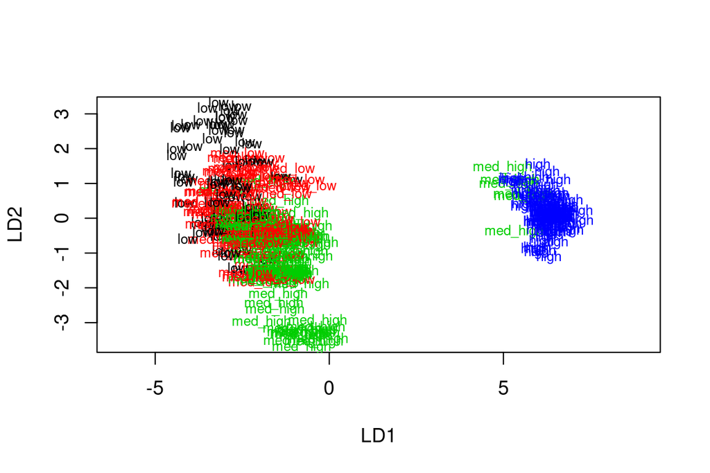

```r
classes = as.numeric(train$crime)
plot(model, dimen=2, col=classes, pch=classes)
```

Seems like the highest crime quantile is separable from other clusters. We can proceed to the model testing part.

## vi. Testing the prediction

```r
# remove the crime factor from the test set
correct_classes = test$crime
test <- dplyr::select(test, -crime)
str(correct_classes)
```

```
##  Factor w/ 4 levels "low","med_low",..: 1 1 1 3 3 3 1 1 2 1 ...
```

```r
str(test)
```

```
## 'data.frame':    102 obs. of  13 variables:
##  $ zn     : num  -0.487 -0.487 -0.487 -0.487 -0.487 ...
##  $ indus  : num  -0.593 -0.593 -1.306 -0.437 -0.437 ...
##  $ chas   : num  -0.272 -0.272 -0.272 -0.272 -0.272 ...
##  $ nox    : num  -0.74 -0.74 -0.834 -0.144 -0.144 ...
##  $ rm     : num  0.194 1.281 0.207 -0.476 -0.831 ...
##  $ age    : num  0.367 -0.266 -0.351 0.477 0.939 ...
##  $ dis    : num  0.55661 0.55661 1.07667 0.09259 -0.00372 ...
##  $ rad    : num  -0.867 -0.867 -0.752 -0.637 -0.637 ...
##  $ tax    : num  -0.986 -0.986 -1.105 -0.601 -0.601 ...
##  $ ptratio: num  -0.303 -0.303 0.113 1.175 1.175 ...
##  $ black  : num  0.441 0.396 0.41 -1.359 0.023 ...
##  $ lstat  : num  -0.492 -1.208 -1.042 2.109 0.798 ...
##  $ medv   : num  -0.101 1.323 0.671 -1.015 -1.026 ...
```

Test doesn’t have the correct answer - ok

Prediction of crime categories with LDA using the prepared test data:

```r
predictions = predict(model, newdata=test)

# Cross tabulate the results with the crime categories from the test set.
table(correct=correct_classes, predicted=predictions$class)
```

```
##           predicted
## correct    low med_low med_high high
##   low       24      14        1    0
##   med_low    5      12        9    0
##   med_high   1       5       13    0
##   high       0       0        1   17
```

This produces quite a fair confusion matrix with a strong diagonal. Some confusion between low and med_low is apparent, otherwise this is very OK.

## vii. k-means

Let’s reload and standardize the Boston dataset

```r
data("Boston")

# Scale the variables to mean zero and unit variance

boston_sc <- as.data.frame(scale(Boston))

# This is one of my favorite methods in R. (besides the heatmap)

dist_eu <- dist(boston_sc, method="euclidean")
summary(dist_eu)
```

```
##    Min. 1st Qu.  Median    Mean 3rd Qu.    Max.
##  0.1343  3.4625  4.8241  4.9111  6.1863 14.3970
```

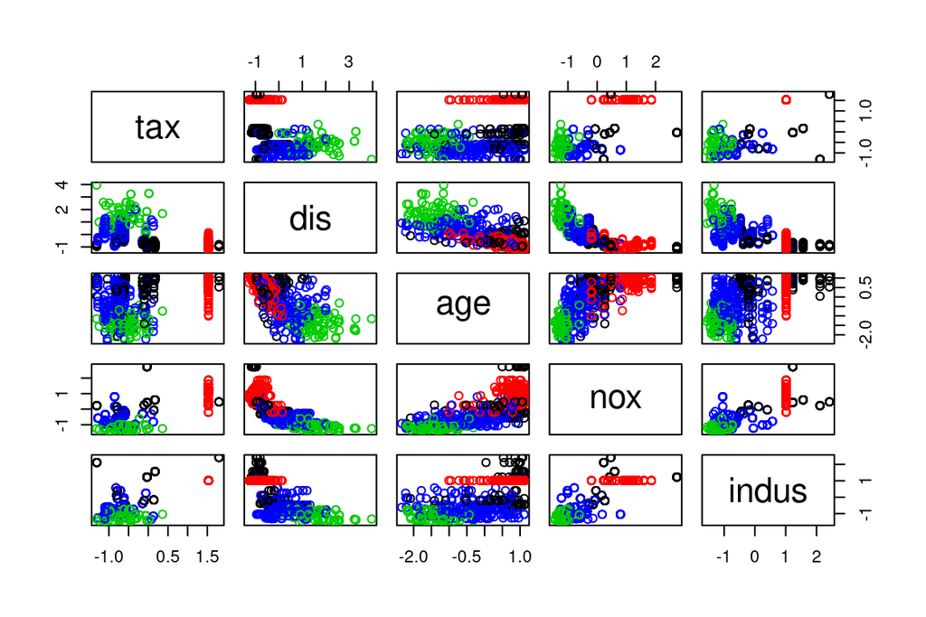

```r
# Running k-means algorithm on the dataset.
# What is the optimal number of clusters? Try 4 ...

km <- kmeans(boston_sc, centers=4)

# Visualize the with a few variables as pairs
pairs(boston_sc[c('tax','dis','age',
                  'nox','indus')], col=km$cluster)
```

Ok.

Seems like there are some clusters found, since we see some connection between the cluster color and the xy-position on the plot.

Let’s run the k-means again to find an optimal number of k clusters.

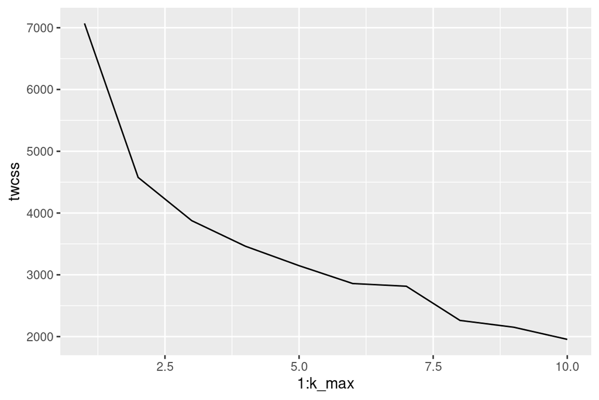

```r
# boston_sc dataset is available
set.seed(123)

# determine the number of clusters
k_max <- 10

# calculate the total within sum of squares
twcss <- sapply(1:k_max, function(k){kmeans(boston_sc, k)$tot.withinss})

# visualize the results
qplot(x = 1:k_max, y = twcss, geom = 'line')
```

Seems like there is a drop at 2 clusters.

Let us do the clustering again with centers=2

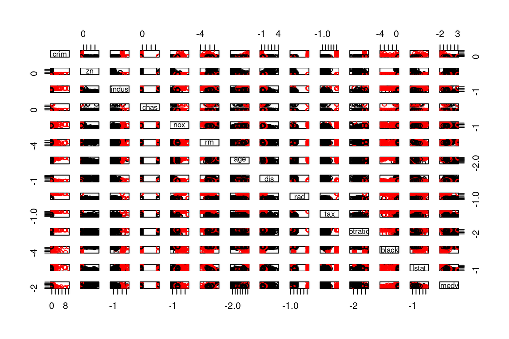

```r
# k-means clustering
km <-kmeans(boston_sc, centers = 2)


# plot the Boston dataset with clusters
pairs(boston_sc, col=km$cluster)
```

Seems to be pretty ok. For a better picture, let’s look at the pairs data with the same variables as before:

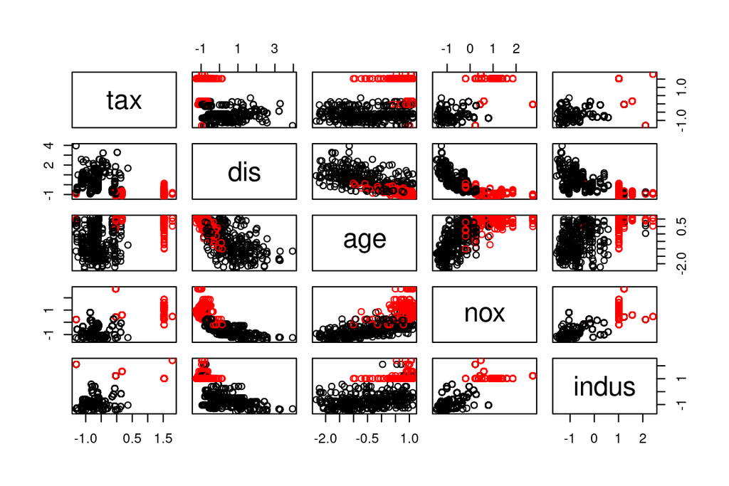

```r
# plot the Boston dataset with clusters
pairs(boston_sc[c('tax','dis','age',
                  'nox','indus')], col=km$cluster)
```

We can be pretty happy with this. There are two distinct clusters. Some bleeding can still be seen, in some pairs but the other dimensions show very distinct split between the clusters.

## extra: Arrows

```r
# Reload the original Boston dataset
data("Boston")

# Scale the variables  again to normalized

boston_sc <- as.data.frame(scale(Boston))

set.seed(123)

# 3 clusters using k-means for targets
km <- kmeans(boston_sc, centers=3)

#  LDA using the km clusters
lda.fit <- lda(x=boston_sc, grouping=km$cluster)

# Examine the object
lda.fit
```

```
## Call:
## lda(boston_sc, grouping = km$cluster)
##
## Prior probabilities of groups:
##         1         2         3
## 0.2806324 0.3992095 0.3201581
##
## Group means:
##         crim         zn        indus        chas         nox         rm
## 1  0.9693718 -0.4872402  1.074440092 -0.02279455  1.04197430 -0.4146077
## 2 -0.3549295 -0.4039269  0.009294842  0.11748284  0.01531993 -0.2547135
## 3 -0.4071299  0.9307491 -0.953383032 -0.12651054 -0.93243813  0.6810272
##          age        dis        rad        tax     ptratio      black
## 1  0.7666895 -0.8346743  1.5010821  1.4852884  0.73584205 -0.7605477
## 2  0.3096462 -0.2267757 -0.5759279 -0.4964651 -0.09219308  0.2473725
## 3 -1.0581385  1.0143978 -0.5976310 -0.6828704 -0.53004055  0.3582008
##         lstat       medv
## 1  0.85963373 -0.6874933
## 2  0.09168925 -0.1052456
## 3 -0.86783467  0.7338497
##
## Coefficients of linear discriminants:
##                 LD1         LD2
## crim     0.03654114  0.20373943
## zn      -0.08346821  0.34784463
## indus   -0.32262409 -0.12105014
## chas    -0.04761479 -0.13327215
## nox     -0.13026254  0.15610984
## rm       0.13267423  0.44058946
## age     -0.11936644 -0.84880847
## dis      0.23454618  0.58819732
## rad     -1.96894437  0.57933028
## tax     -1.10861600  0.53984421
## ptratio -0.13087741 -0.02004405
## black    0.15432491 -0.06106305
## lstat   -0.14002173  0.14786473
## medv     0.02559139  0.37307811
##
## Proportion of trace:
##    LD1    LD2
## 0.8999 0.1001
```

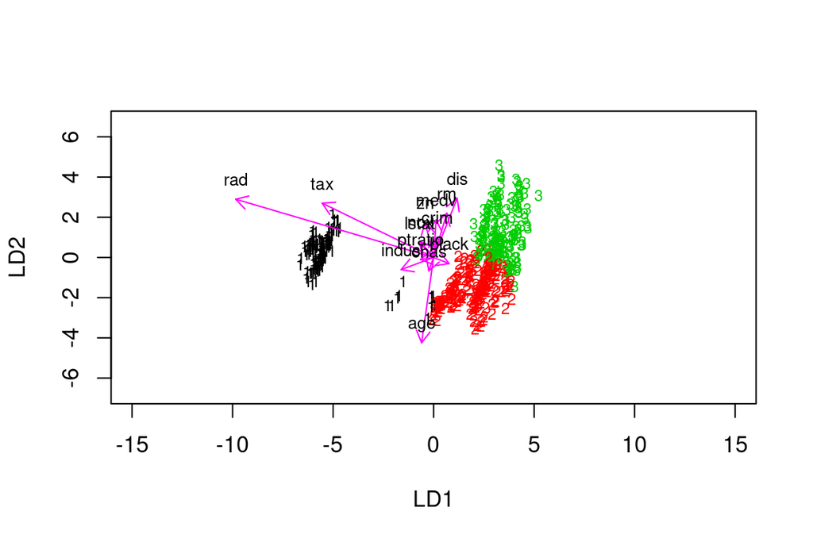

```r
# now with arrows as in the datacamp task
lda.arrows <- function(x, myscale = 1, arrow_heads = 0.1,
                       color = "magenta", tex = 0.75, choices = c(1,2))
  {
  heads <- coef(x)
  arrows(x0 = 0, y0 = 0,
         x1 = myscale * heads[,choices[1]],
         y1 = myscale * heads[,choices[2]], col=color, length = arrow_heads)
  text(jitter(myscale * heads[,choices]), labels = row.names(heads),
       cex = tex, col="black", pos=3)
}

# Plot with arrows
plot(lda.fit, dimen = 2, col=km$cluster, pch=km$cluster, ylim=c(-7,7),xlim=c(-10,10))
lda.arrows(lda.fit, myscale = 5)
```

Two possible separate clusters could be explained by: i) high value homes and large lots (by surface area) and ii) the closeness to radial highways.

This clustering seems very appropriate, and we can be happy with this.